# Time Series

18BCE1104 - Ankita Duraphe

11/02/2021

### Forecasting

highest Petrol price in every month from 2018 to yesterday

```r
data_vector = c(75.63, 76.12, 76.29, 77.47, 81.47, 81.32, 79.8, 81.63, 86.8, 87.39, 82.51, 75.34,74.03, 74.43, 75.65, 75.96, 75.9, 74.39, 76.29, 75.65, 77.34, 77.56, 77.763, 78.1, 79.04, 76.01, 74.79, 72.37, 75.78, 83.63, 83.67, 85.05, 85.09, 84.19, 85.31, 86.51, 88.8, 89.68)
```

converting vector to dataset

```r
data_forecasting = ts(data_vector, start=c(2018,1), end=c(2021,2), frequency=12)
```

importance of spliting automatically

```r
start(data_forecasting)
```

```
## [1] 2018    1
```

```r
end(data_forecasting)
```

```
## [1] 2021    2
```

```r
frequency(data_forecasting)
```

```
## [1] 12
```

```r
cycle(data_forecasting)
```

```
##      Jan Feb Mar Apr May Jun Jul Aug Sep Oct Nov Dec
## 2018   1   2   3   4   5   6   7   8   9  10  11  12
## 2019   1   2   3   4   5   6   7   8   9  10  11  12
## 2020   1   2   3   4   5   6   7   8   9  10  11  12
## 2021   1   2
```

```r
summary(data_forecasting)
```

```
##    Min. 1st Qu.  Median    Mean 3rd Qu.    Max.
##   72.37   75.81   77.66   79.60   83.66   89.68
```

Analysis PART: plotting the series

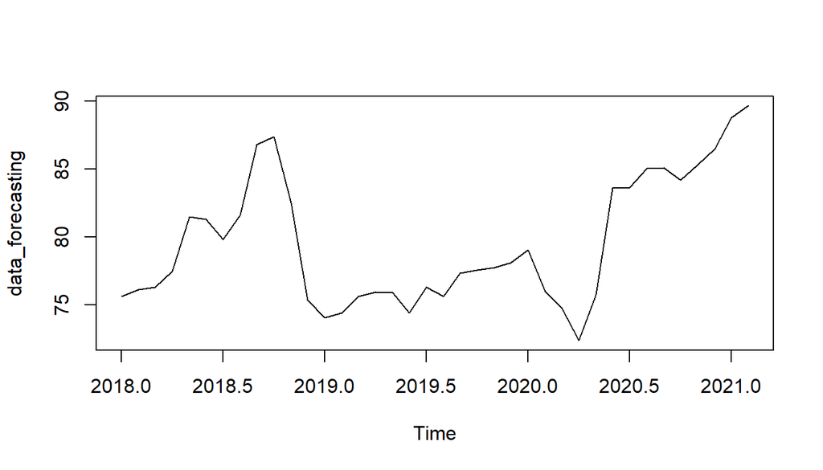

```r
plot(data_forecasting)
```

regression

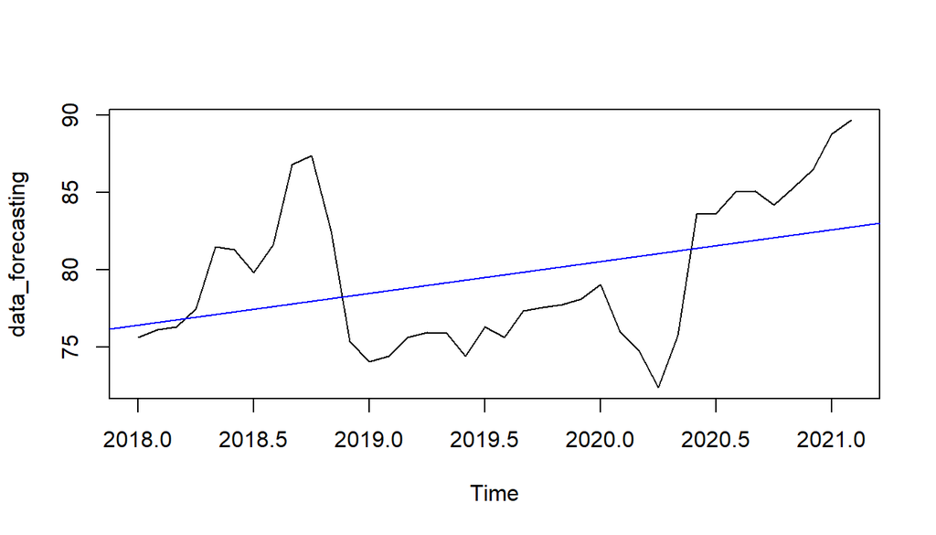

```r
plot(data_forecasting)
abline(reg=lm(data_forecasting~time(data_forecasting)), col="blue")
```

month-wise (range and mean) plot

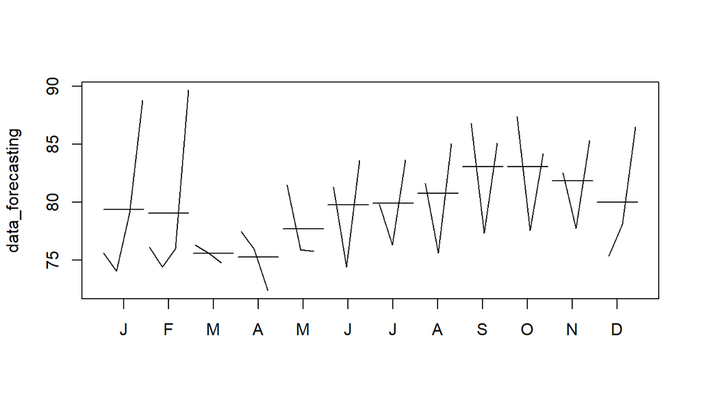

```r
monthplot(data_forecasting)
```

year-wise mean plot

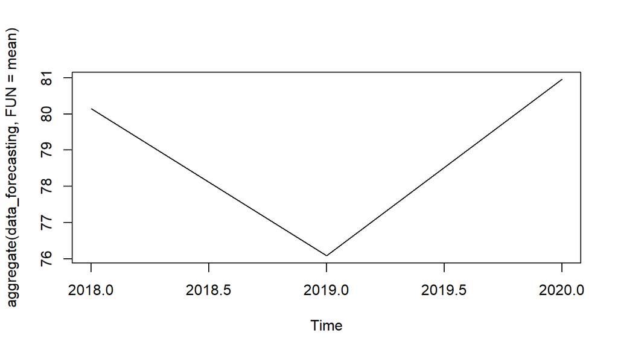

```r
plot(aggregate(data_forecasting,FUN=mean))
```

month-wise box plot

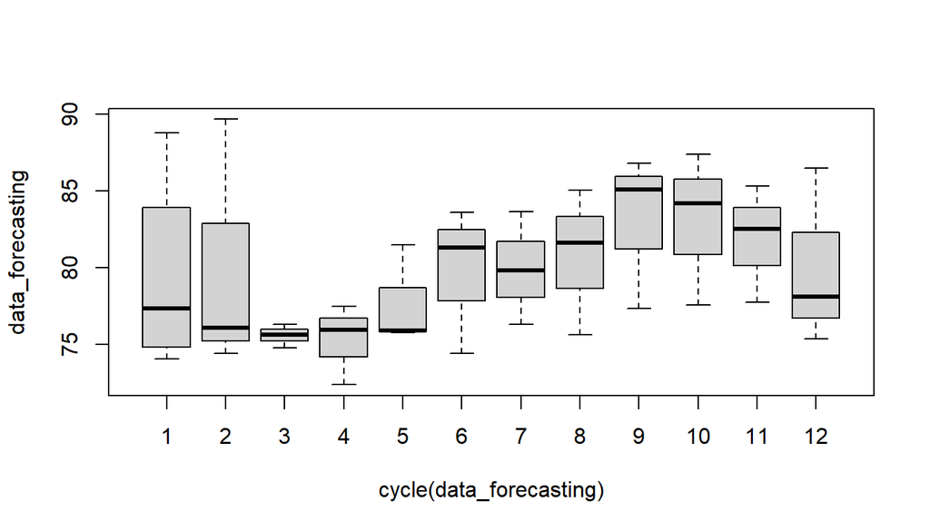

```r
boxplot(data_forecasting~cycle(data_forecasting))
```

Load the required packages

```r
library(fabletools)
```

```r
library(ggplot2)
library(forecast)
library(ggfortify)
```

visualisation

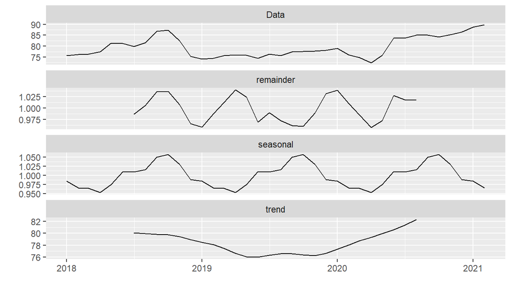

```r
decompose_fc = decompose(data_forecasting,"multiplicative")
autoplot(decompose_fc)
```

FORECASTING / PREDICTING: install.packages(“forecast”)

```r
library(forecast)
```

Monthwise predicting

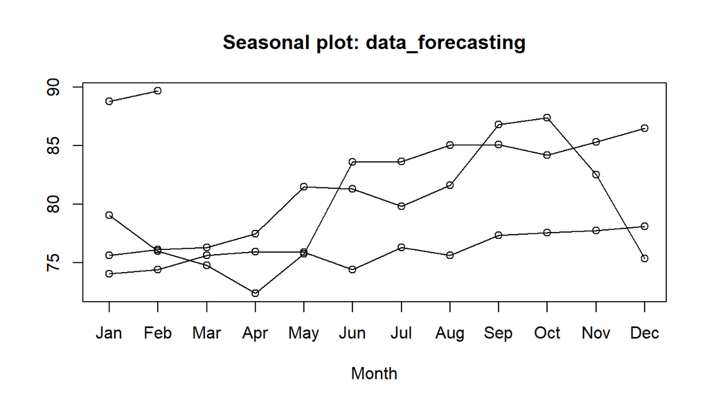

```r
seasonplot(data_forecasting)
```

Autocorrelation and Partial Autocorrelation plots

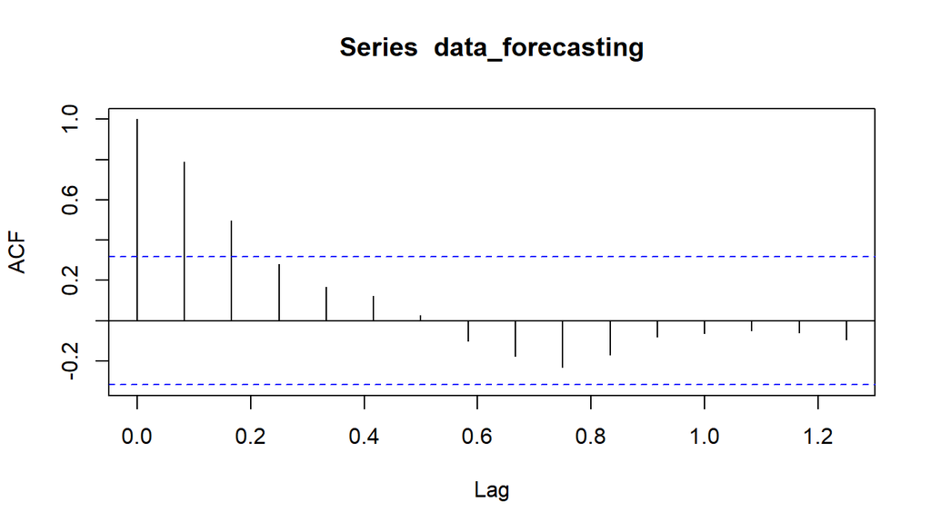

```r
acf(data_forecasting)   #for MA - Q
```

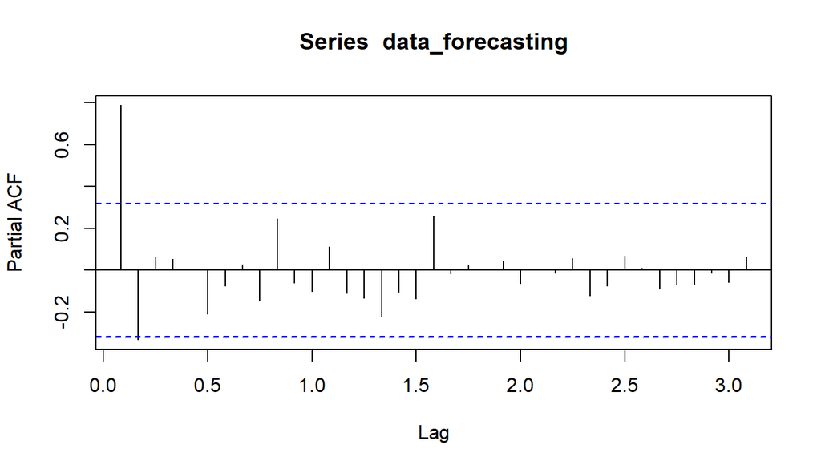

```r
pacf(data_forecasting, lag=length(data_forecasting),pl=TRUE) # for AR - P
```

ARIMA AR (P - autoregressive lags) + I (d - order of differentiation) + MA (Q - moving average) correlation between previous time period with current noise | averaging / smoothing

```r
fit_arima = arima(data_forecasting, order=c(3, 2, 2))
accuracy(fit_arima)
```

```
##                      ME     RMSE      MAE         MPE     MAPE      MASE
## Training set 0.01807052 2.197007 1.632346 -0.01379927 2.039507 0.9485911
##                      ACF1
## Training set -0.006140107
```

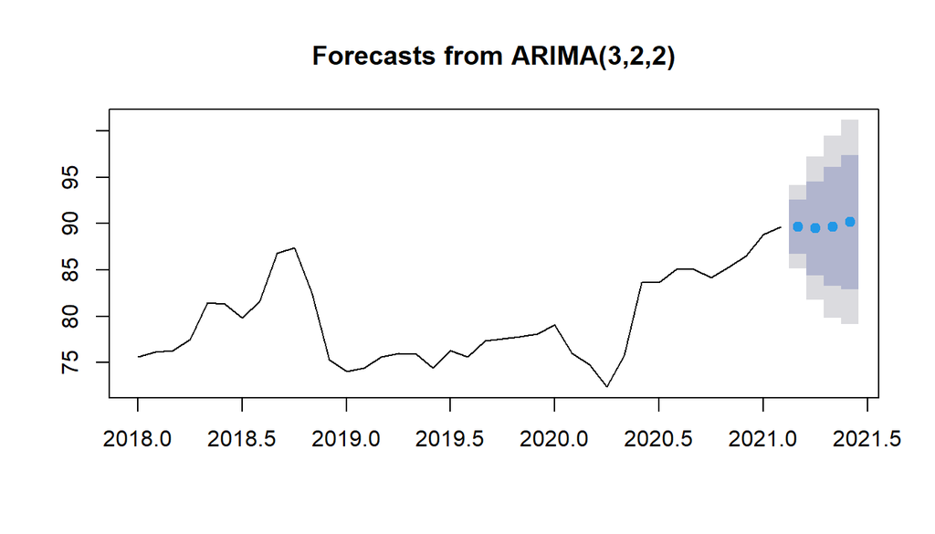

```r
newdata_arima = forecast(fit_arima, 4)
plot(newdata_arima)
```

Auto ARIMA

```r
fit_autoarima = auto.arima(data_forecasting)
accuracy(fit_autoarima)
```

```
##                     ME     RMSE      MAE       MPE     MAPE      MASE
## Training set 0.3113201 2.251578 1.679884 0.3445943 2.103429 0.3008596
##                     ACF1
## Training set -0.05613608
```

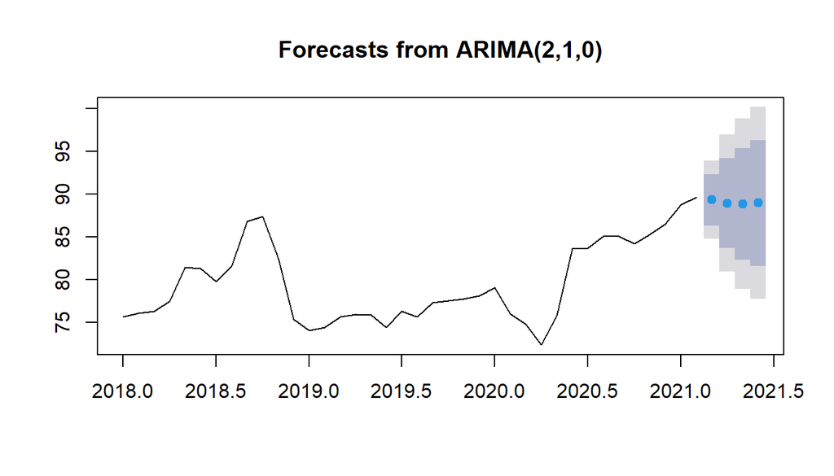

```r
newdata_autoarima = forecast(fit_autoarima, 4)
plot(newdata_autoarima)
```

### Forecasting for Weather History dataset

Load the required packages

```r
library(ggplot2)
library(dplyr)
```

Read the dataset

```r
data <- read.csv("weatherHistory.csv")
```

View the dataset

```r
View(data)
```

Converting To Time Series object using ts() function: For Weekly data

```r
weather_forecasting = ts(data$Humidity, start=c(2006,1,4), end=c(2016,9,9), frequency=7)
```

importance of spliting automatically

```r
start(weather_forecasting)
```

```
## [1] 2006    1
```

```r
end(weather_forecasting)
```

```
## [1] 2017    2
```

```r
frequency(weather_forecasting)
```

```
## [1] 7
```

```r
cycle(weather_forecasting)
```

```
## Time Series:
## Start = c(2006, 1)
## End = c(2017, 2)
## Frequency = 7
##  [1] 1 2 3 4 5 6 7 1 2 3 4 5 6 7 1 2 3 4 5 6 7 1 2 3 4 5 6 7 1 2 3 4 5 6 7 1 2 3
## [39] 4 5 6 7 1 2 3 4 5 6 7 1 2 3 4 5 6 7 1 2 3 4 5 6 7 1 2 3 4 5 6 7 1 2 3 4 5 6
## [77] 7 1 2
```

```r
summary(weather_forecasting)
```

```
##    Min. 1st Qu.  Median    Mean 3rd Qu.    Max.
##  0.3600  0.6050  0.7900  0.7372  0.8800  0.9900
```

Analysis PART: plotting the series

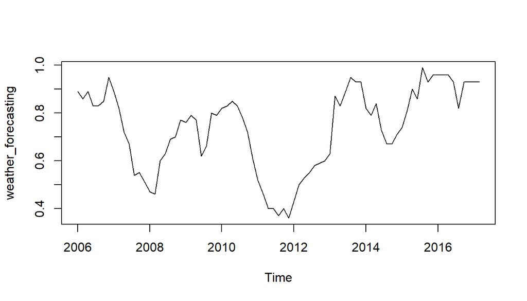

```r
plot(weather_forecasting)
```

regression

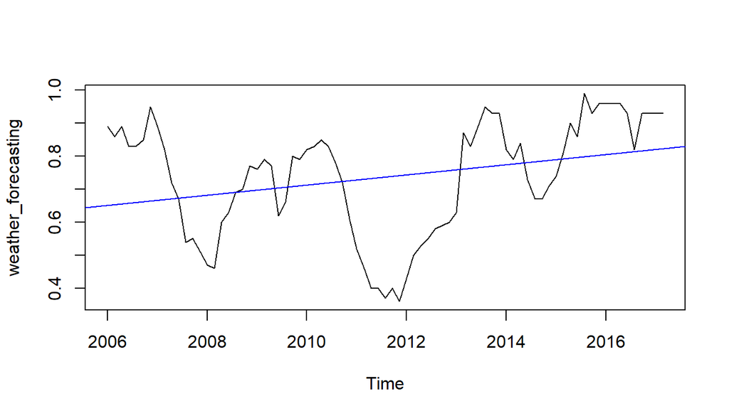

```r
plot(weather_forecasting)
abline(reg=lm(weather_forecasting~time(weather_forecasting)), col="blue")
```

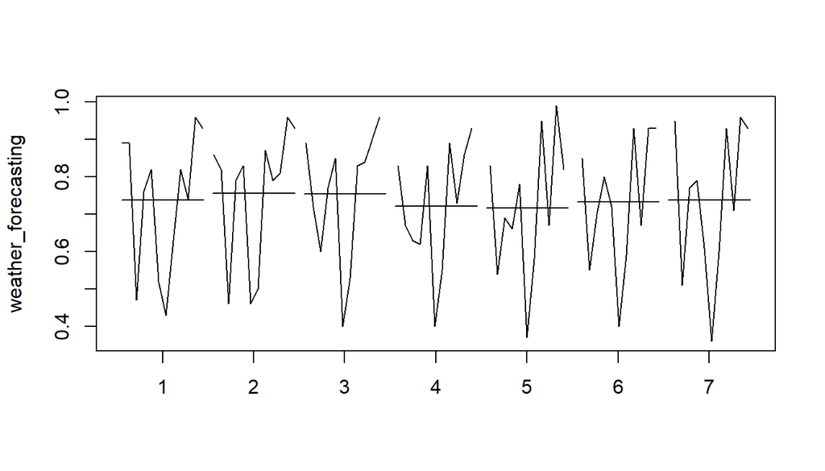

```r
monthplot(weather_forecasting)
```

year-wise mean plot

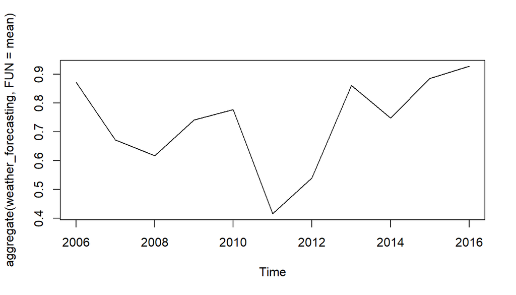

```r
plot(aggregate(weather_forecasting,FUN=mean))
```

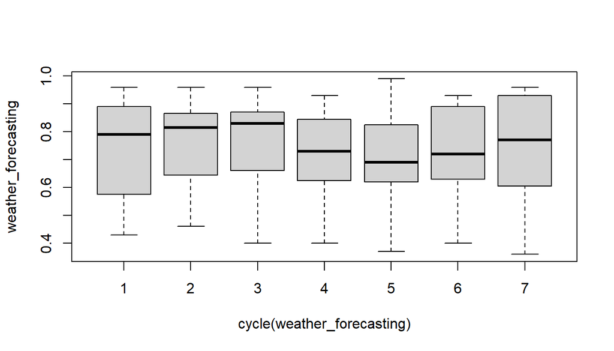

```r
boxplot(weather_forecasting~cycle(weather_forecasting))
```

visualisation

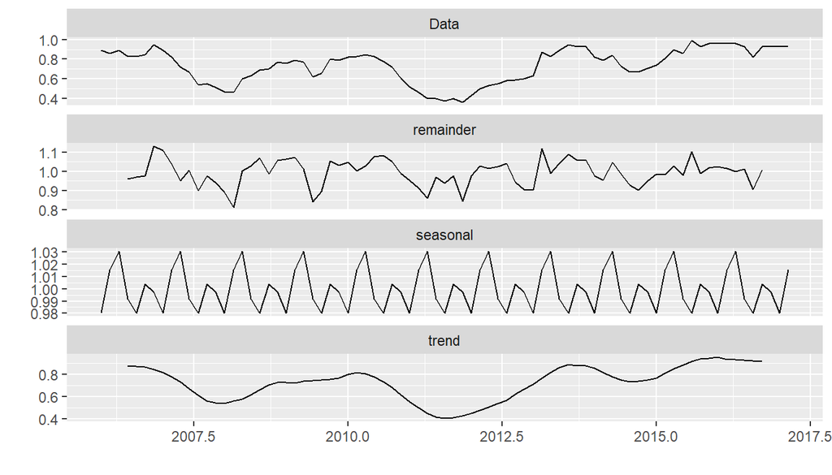

```r
decompose_fc = decompose(weather_forecasting,"multiplicative")
autoplot(decompose_fc)
```

FORECASTING / PREDICTING: install.packages(“forecast”)

```r
library(forecast)
```

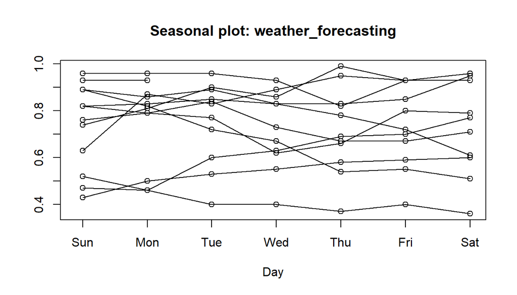

```r
seasonplot(weather_forecasting)
```

Autocorrelation and Partial Autocorrelation plots

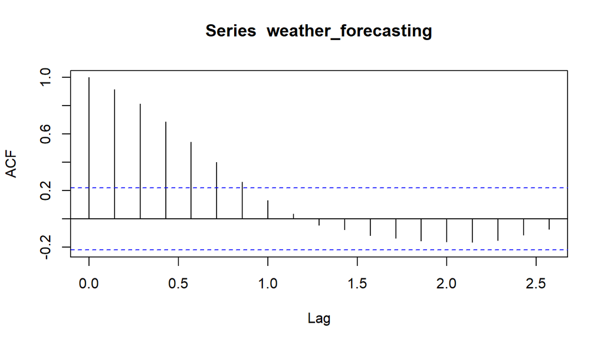

```r
acf(weather_forecasting)   #for MA - Q
```

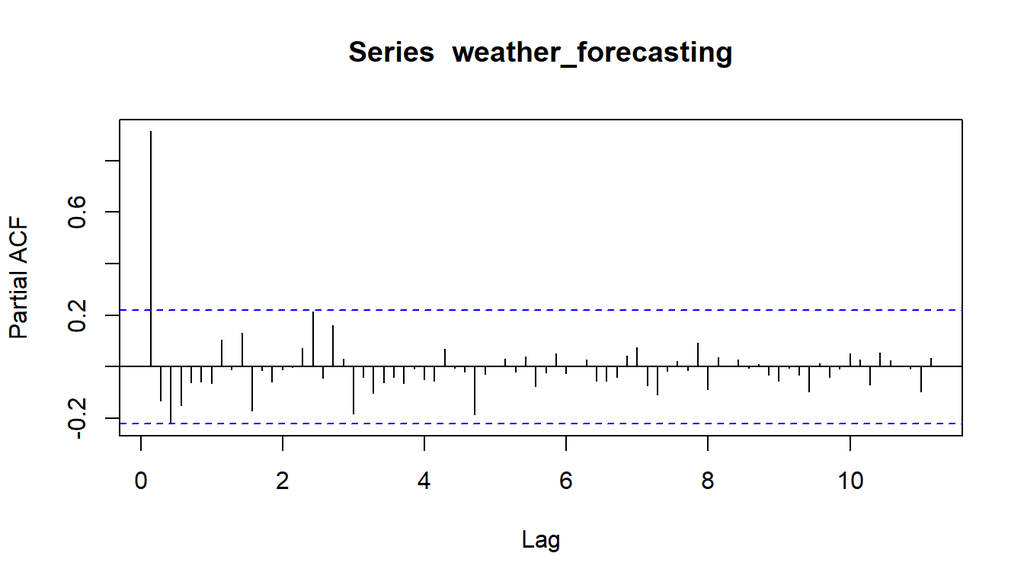

```r
pacf(weather_forecasting, lag=length(weather_forecasting),pl=TRUE) # for AR - P
```

ARIMA AR (P - autoregressive lags) + I (d - order of differentiation) + MA (Q - moving average) correlation between previous time period with current noise | averaging / smoothing

```r
fit_arima = arima(weather_forecasting, order=c(3, 2, 2))
accuracy(fit_arima)
```

```
##                      ME       RMSE        MAE       MPE    MAPE      MASE
## Training set 0.00494041 0.06445767 0.04667016 0.7026935 6.57561 0.9430757
##                    ACF1
## Training set -0.0154765
```

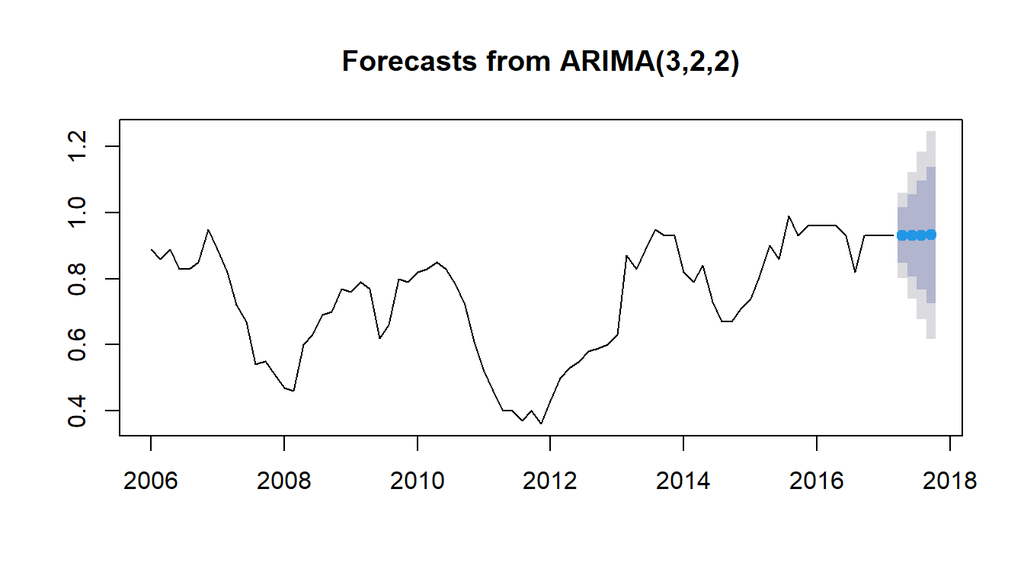

```r
newdata_arima = forecast(fit_arima, 4)
plot(newdata_arima)
```

Auto ARIMA

```r
fit_autoarima = auto.arima(weather_forecasting)
accuracy(fit_autoarima)
```

```
##                        ME       RMSE        MAE        MPE     MAPE      MASE
## Training set 0.0005175949 0.06606487 0.04887203 -0.3998971 7.069131 0.2600729
##                   ACF1
## Training set 0.1100771
```

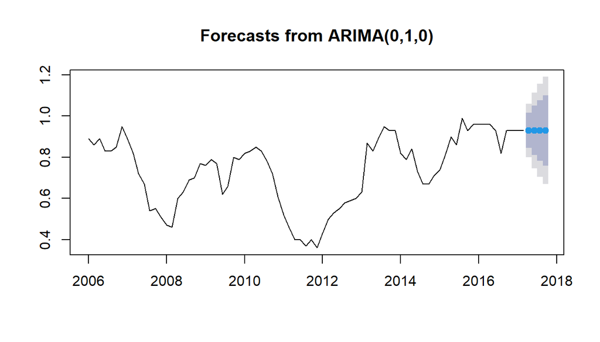

```r
newdata_autoarima = forecast(fit_autoarima, 4)
plot(newdata_autoarima)
```